# Genética Quantitativa

## Tarefa

- Read chapter 7 from Lynch & Walsh (1998) until page 139.
- (Optional) Read Jacquard (1972).
- Explain the content of slides 12 for an undergraduated student that is seeing it for the first time (30 lines).

### Minha Resposta

- Explain the content of slides 12 for an undergraduated student that is seeing it for the first time (30 lines).

*Entender o grau de relacionamento entre indivíduos é válido, através dele pois é possível estimar indiretamente fenótipos que não estão sendo observados. Para alcançar esse grau primeiramente é preciso estabelecer um período de tempo de referência, pois, devido ao ancestral comum, se voltarmos muitas gerações algum grau de parentesco os indivíduos irão possuir. Podemos utilizar três medidas:*

*- Identidade por descendência (IBD): alelos são cópias provenientes de um ancestral comum;*

*- Identidade por estado (IBS): alelos que são idênticos porém não são provenientes de um ancestral comum;*

*- Endogamia: par de alelos IBD em um indivíduo.*

*Considerando dois indivíduos (x e y) e um gene, seus 4 alelos possuem 15 possibilidades de relacionamento, que foram descritas por Jacquard (1972) - Δ1 à Δ9. A partir das descrições de Jacquard, temos um modelo generalizado para calcular o Coeficiente de Coancestria (Θxy) de qualquer população, que é uma medida de probabilidade ao se tomar um gene ao acaso de dois indivíduos eles serem IBD. Dada por:* *Θxy = Δ1 + 1/2(Δ3 + Δ5 + Δ7) + 1/4Δ8*

*Em que Δ é a probabilidade de dado estado de identidade. E quanto maior o Θxy, mais aparentados os indivíduos são.*

*No slide 10, são apresentados 3 casos específicos e o seu coeficiente de coancestria.*

*No primeiro caso, a medida é entre parentais e sua progênie. Nesse caso, o único estado de identidade possível é o Δ8. Seja x o parental e y, a progênie e que eles não são endogâmicos, já se exclui os Δ1 ao Δ6. O Δ7 é excluído pois o parental só pode passar 1 dos alelos à progênie, e nesse estado 2 são IBD. O Δ9 é excluído, pois pelo menos 1 alelo deve ser passado pela progênie, e nesse estado nenhum é IBD. Assim sobra apenas o estado Δ8. Dessa forma, a probabilidade se ser meio será 1 e o Θxy 0,25.*

*O segundo caso, os indivíduos x e y são irmãos completos. Nesse caso, eles podem compartilhar por IBD 2 alelos provenientes dos parentais (Δ7), 1 alelo (Δ8), ou nenhum (Δ9).*

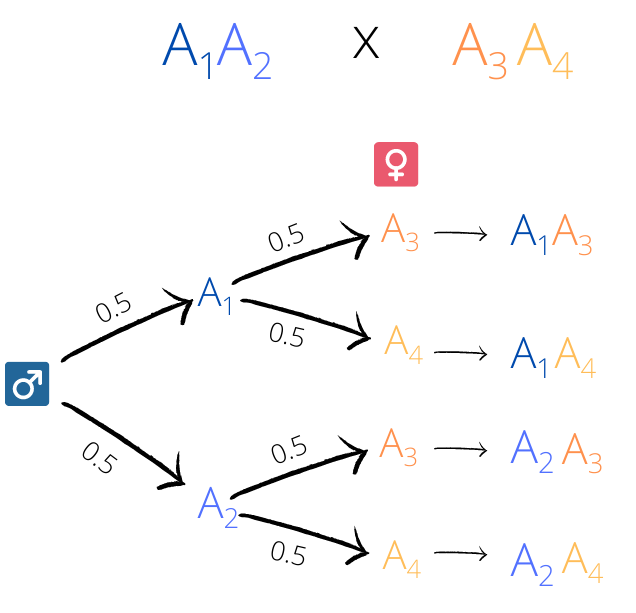

Genótipos possíveis

*Dado o indivíduo x ter um alelo, a probabilidade do y ter o mesmo é 0,5, assim, a probabilidade dos indivíduos possuírem o alelo maternal e o paternal iguais é 0,25. Dessa forma, Δ7 será 0,25.*

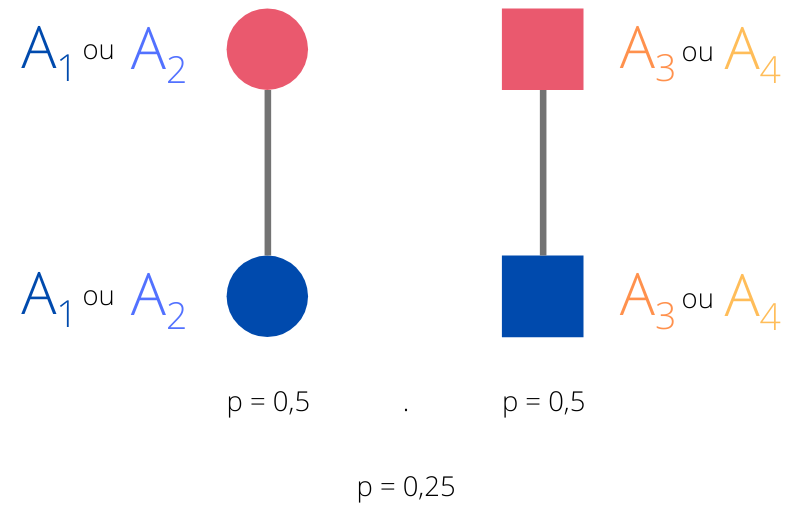

Δ7

*Para o Δ8 a probabilidade é dado o indivíduo x ter um alelo o indivíduo y ter o mesmo, ou seja, é 0,5.*

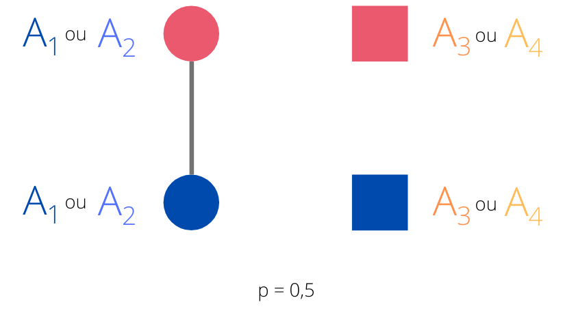

Δ8 para irmãos completos.

*E para o Δ9 a probabilidade será a a probabilidade dos indivíduos possuírem os alelos maternal e o paternal diferentes, ou seja, 0,25. Assim, aplicando o modelo geral temos que Θxy é 0,25.*

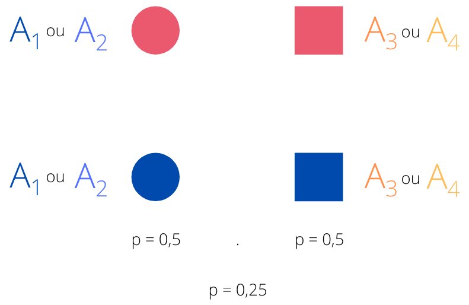

Δ9 para irmãos completos.

*No terceiro caso, os indivíduos são meio-irmãos, dessa forma, há a possibilidade deles compartilharem 1 alelo IBD (Δ8) ou nenhum (Δ9). Para o Δ9, seu valor será a probabilidade do alelo parental compartilhado ser diferente, ou seja, 0,5. Assim, aplicando o modelo geral temos que Θxy é 0,125.*

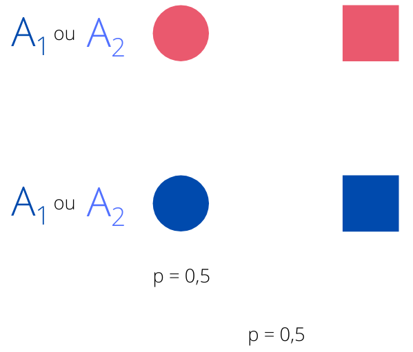

Δ9 para meio-irmãos.

# Aula 10 - Semelhança Entre Parentes II: Fraternidade entre Parentes

## Coeficiente de Endogamia

Considere um indivíduo z que é progênie de x e y. $\theta_{xy}$ é a probabilidade de 2 genes em um loco de z forem ibd. O coeficiente de endogamia é dado o indivíduo z ser progênie de x e y a probabilidade de 2 genes serem ibd, ou seja, mede o grau de parentesco entre x e y, pois eles serão iguais se os parentais tiverem algum grau de parentesco.

$$f_z = \Theta_{xy}$$

## Algumas derivações

**Indivíduo com ele mesmo**

- Sem endogamia ($A_1$, $A_2$):

$$\Theta_{xy} = \frac{1}{4} + \frac{1}{4}
= \frac{1}{2}$$

- Com endogamia ($A_1$, $A_2$):

$$\Theta_{xy} = \frac{1}{4} +
\frac{1}{4}f_x + \frac{1}{4} + \frac{1}{4}f_x =
\frac{1}{2}(1+f_x)$$

**Pais e Filhos:**
$$\Theta_{po} = \frac{1}{4} (1 + f_p +
2f_o)$$

**Irmãos Completos(m: mãe, f: pai):**
$$\Theta_{xy} = \frac{1}{8} (2 + f_m + f_f +
4\Theta_{mf})$$

Sem endogamia:

$$\Theta_{xy} = \frac{1}{4}$$

## Cálculo (Falconer e Mackay, 1996)

$$f_z = \sum \frac{1}{2}^n.(1+
f_{ancentral})$$

n = número de indivíduos no caminho.

## Coeficiente de fraternidade

Probabilidade de um genótipo de loco único de dois indivíduos sejam ibd (probabilidade que dois idivíduos sejam ibd’s pro genótipo):

*Notação:* mães de x e y são $m_{x}$ e $m_{y}$, pais são $f_{x}$ e $f_{y}$

Portanto,

$$\Delta_{xy} =
\Theta_{m_xm_y}.\Theta_{f_xf_y} +
\Theta_{m_xf_y}.\Theta_{f_xm_y}$$

ou

$$\Delta_{xy} = \Delta_1 +
\Delta_7$$

*Sem endogamia:* $\Delta_{xy} = \Delta_7$

## Covariância genética entre indivíduos aparentados

**Pressupostos:**

- Diplóide;
- Cruzamento aleatório;
- Sem desequilíbrio de ligação;
- Sem GxE e covariância G,E.

Pegamos 2 indivíduos de uma população onde todos os membros têm o mesmo relacionamento:

$$\sigma_G(x,y) = \sigma_A(x,y) +
\sigma_D(x,y) + \sigma_{AA}(x,y) + \sigma_{AD}(x,y) + \sigma_{DD}(x,y) \
...$$

## Covariância Genética Aditiva

A covariância entre x e y causada pelos efeitos aditivos é:

$$E[(\alpha_i^x + \alpha_j^x)(\alpha_i^y +
\alpha_j^y)]$$

A única forma da esperaça não ser 0 é se o alelo i for o mesmo nos indivíduos x e y, se isso ocorrer, então:

$$E[(\alpha_i^x + \alpha_i^y) =
E(\alpha_i^2)$$

(metade da variância genética aditiva)

E a probabilidade de i ser o mesmo é $\Theta_{xy}$, dessa forma temos a esperança como:

$$4\Theta_{xy}E(\alpha_i^2)$$

(Duas vezes a variância genética aditiva para o loco vezes $\Theta_{xy}$)

*para todos os locus:*
$$\sigma_A(x,y) =
2\Theta_{xy}\sigma_A^2$$

## Covariância Genética de Dominância

$$E(\delta_{ij}^x\delta_{ij}^y)$$

Os indivíduos precisam ter o mesmo genótipo. Se x e y são ibd para ambos os locus, então:

$$E(\delta_{ij}^x\delta_{ij}^y) =
E(\delta{ij}^2)$$

Essa identidade tem uma probabilidade igual à $\Delta_{xy}$. Então:

$$\sigma_D(x,y) =
\Delta_{xy}\sigma_D^2$$

## Covariância Epistática

Precisa ter o mesmo alelo ibd:

$$\sigma_{AA}(x,y) = (2\Theta_{xy})^2
\sigma_{AA}^2$$

$$\therefore \ \sigma_G(x,y) =
2\Theta_{xy}\sigma_{A}^2 + \Delta_{xy} \sigma_{D}^2 + (2\Theta_{xy})^2
\sigma_{AA}^2 + 2\Theta_{xy} \Delta_{xy} \sigma_{AD}^2 + \Delta_{xy}^2
\sigma_{DD}^2$$

## Componentes de Variância

Essa covariâncias podem ser usadas para estimar os componentes de variância:

*Casos particulares:*

| Relação | $\sigma_{A}^{2}$ | $\sigma_{D}^{2}$ | $\sigma_{AA}^{2}$ | $\sigma_{AD}^{2}$ | $\sigma_{DD}^{2}$ |
| --- | --- | --- | --- | --- | --- |
| Pais e filhos | $\frac{1}{2}$ |  | $\frac{1}{4}$ |  |  |
| Meios-irmãos | $\frac{1}{4}$ |  | $\frac{1}{16}$ |  |  |
| Irmãos completos | $\frac{1}{2}$ | $\frac{1}{4}$ | $\frac{1}{4}$ | $\frac{1}{8}$ | $\frac{1}{16}$ |

## Tarefa

### Minha Resposta

# Aula 11 - Estimação I: Efeitos Genéticos e Variâncias, Média e Análises One-Way

## Introdução

Abordagem tradicional baseada apenas em dados fenotípicos para estudar populações, arquitetura gênica, definir estratégias de melhoramento.

**Expectativa para média de linhas de cruzamento**

- duas populações parentais: $P_1$ e $P_2$;
- Cada loco em equilíbrio de HW e equilíbrio de fase gamética;
- As populações não são ligadas;
- $F_1$: cruzamento das linhas $P_1$ e $P_2$;
- $F_1$: cruzamento entre indivíduos $F_1$.

**Definições:**

**S** - fração de genes $P_1$ em uma linha;

**H** - probabilidade que um membro de uma linha tenha um $P_1$ e um $P_2$ em um loco;

Frequência esperada das 3 classes genotípicas:

- $S - \frac{H}{2}$: frequência de indivíduos com apenas alelos $P_1$;
- H: frequência de indivíduos com um alelo $P_1$ e um $P_2$;
- $1 - S - \frac{H}{2}$: frequência de indivíduos com apenas alelos $P_2$.

**Efeito Composto**

Diferença dos efeitos aditivos dos alelos $P_1$ e $P_2$ somado para todos os locu. Se uma população com efeitos complementares pode haver um cancelamento de efeitos.

**Efeitos Aditivos Compostos**

$F_2$: frequência de alelos contrastante é 1/2.

Efeito de $P_1 = \frac{+ \alpha^c}{2}$

Efeito de $P_2 = \frac{- \alpha^c}{2}$

Efeito aditivo composto total: $\frac{\alpha^c - \alpha^c}{2}$

Isso é conveniente para uma população de referência.

**Efeitos Aditivos e de Dominância Compostos**

Contribuição do composto aditivo na média do valor genotípico de qualquer linha de cruzamento derivada de: (todas populações)

$$\left(S - \frac{H}{2} \right)(\alpha^c)
+ (H)(0) + (1 - S - \frac{H}{2})(- \alpha^c) \\
= (2S-1)(\alpha^c) = \theta_S \alpha^c$$

- $\theta_s = 2S - 1$: indice de onde veio o alelo (fonte de origem);
- $\theta_s$: contraste do número esperado de alelos $P_1$ em um loco em uma linha particular (2S) em uma população de referência $F_2$.

Lembrando que $\delta$ são desvios, temos que:

$$\left(S - \frac{H}{2} \right)(-
\delta^c) + (H)(+ \delta^c) + (1 - S - \frac{H}{2})(- \delta^c) \\
= (2H-1)(\delta^c) = \theta_H \delta^c$$

- $\theta_H = 2H -1$ é o índice do híbrido.

**Média do valor genotípico**

Eu posso definir a média de qualquer população por:

$$\mu = \mu_0 + \theta_S \alpha_1^c +
\theta_H \delta_1^c + \theta_S \alpha_2^c + \theta_S
\theta_H(\alpha_1^c\delta_1^c) + \theta_H^2 \delta_2^c + \cdots
+$$

- $\alpha_2^c$ está relacionado com $\alpha_{11}$ e $\alpha_{22}$ (epistasia axa);
- Esses índices são interpopulacionais.

*Exemplo:*

[output not shown]

$B_1 = S = 3/4 (1/2AA : 1/2 Aa)$, $\theta_S = (2.\frac{3}{4}) - 1 = 1/2$

$\theta_S$ e $\theta_H$ são indices que vão depender da população, por exemplo, em $P_1$ quantos indivíduos tem $P_1$? 100%. Ou seja, S = 1.

$\therefore \theta_S = 2.1 -1 = 1$

$\therefore \theta_H = 2.0 -1 = -1$

Então substituindo $\theta_S$ e $\theta_H$ na fórmula geral da média esperada, eu consigo calcular a média esperada de qualquer população.

## Heterose

Quanto $F_1$ diverge da média dos pais

- Quantos é a média dos pais?

$$\mu(P_1, P_2) = \mu_0 - \delta_1^c +
\alpha_2^c + \delta_2^c$$

**Heterose**

$$H = F_1 - \mu(P_1, P_2) \\ =
2\delta_1^c - \alpha_2^c$$

ou

$$H = \delta_1^c -
\frac{\alpha_2^c}{2}$$

$\therefore$ os alelos de uma população depende da dominância sobre a outra. Uma dominância composta, ou seja global. Além disso, preciso de interação $\alpha$ x $\alpha$. (EPISTASIA!!)

Ou seja, a heterose surge em função do genótipo de população ter um efeito de dominância de uma população sobre a outra ou efeito aditivo. O hibrido tem heterose quando os alelos de uma população estão dominando sobre o alelo de outra população.

A heterose é definida em relação ao cruzamento entre populações, não entre linhagens.

## Estimação dos Efeitos Compostos

Com um número de cruzamento, é possível estimar os efeitos compostos.

**Exemplo** $P_1$, $P_2$ e $F_1$ (ignorando a epistasia):

- $\mu (P_1) = \mu_0 + \alpha_1^c - \delta_1^c$
- $\mu (P_1) = \mu_0 - \alpha_1^c - \delta_1^c$
- $\mu (P_1) = \mu_0 + \delta_1^c$

Para incluir mais parâmetros é necessário mais cruzamentos. Essa abordagem é muito utilizada paa características onde os parentais são bem divergentes, então a maioria dos alelos favoráveis se concentram em $P_1$ ou $P_2$. Por exemplo, resistência à doenças.

## Estimação dos Componentes de Variância

Delineamentos de Cruzamento - One-Factor Desing:

- Baseado na covariância entre parentes, permite a estimação das variâncias genéticas.
- Necessitam de cruzamentos e experimentos.
- Baseados apenas em dados fenotípicos.
- É uma abordagem simples e comum para estimar os componentes de variância e pode auxiliar melhoristas, relacionando á práticas comuns.

**Princípios**

- Iniciar com um experimento com um número de indivíduos com algum grau de parentesco. Por exemplo, n famílias de meio-irmãos.
- Assumir que eles são avaliados em um experimento CRD.
- Modelo:

$$y_{ij} = \mu + t_i + e_{ij}$$
$y_{ij}$: fenótipo do j progênie do i parental

$t_i$: efeito do i parental.

**Fisher (1918)** A análise de variância particionando a variância fenotípica total na soma das variâncias de cada fator:

$$\therefore \sigma_y^2 = \sigma_t^2 +
\sigma_e^2$$

- Variância fenotípica é igual a genética mais a ambiental (essa é uma decomposição ortogonal);

Covariância entre membros do mesmo grupo:

$$\sigma(y_{ij}, y_{ij'}) =
\sigma[(\mu + t_i + e_{ij}), (\mu + t_i + e_{ij'})] \\
= \sigma(t_i, t_i) + \sigma(t_i, e_{ij}') + \sigma(e_{ij}, t_i) +
\sigma(e_{ij}, e_{ij'}) \\
= \sigma_t^2$$

*A covariância fenotípica entre membros de um mesmo grupo é igual à variância entre os grupos.*

Por exemplo, em meios-irmãos (HS):

$$\sigma_{(HS)} =
\sigma_{(HS)}^2$$

## ANOVA

Então é necessário estimar $\sigma_e^2$, um delineamento experimental geralmente é utilizado, com replicações (Bernardo, 2010).

Começando com um experimento casualizado:

t - meios-irmãos y - repetições

## Componentes de Variância

$$y_{ij} = \mu + t_i + e_{ij}$$
**Decomposições:**

$$SS_T = \sum_{i=1}^{t} \sum_{i=1}^{r}
(y_{ij} - \bar{y})^2$$

$$SS_T = SS_t + SS_e$$
É possível mostrar que:

$$E(MS_e) = \sigma_e^2$$

$$E(MS_t) = \sigma_e^2 + r
\sigma_t^2$$

Métodos dos momentos:

$$\sigma_t^2 = \frac{MS_t -
MS_e}{r}$$

## Tarefa

### Minha Resposta

# Aula 12 - Estimação II: Variancias Genéticas - Um fator, Desing I e II, Dialelo

## Introdução

A estimação de parâmetros é muito importante para estratégia de melhoramento e estudos de arquitetura genética. Esses métodos nos permitem explorar melhor a arquitetura. A partir dos delineamentos podemos:

- Estimar a resposta à seleção;
- Estimar a performance de um dado cruzamento;
- Tipos de progênies são desenvolvidas e testadas em diversos ambientes;
- Componentes de variância são estimados a partir de quadrados mínimos.

## Pressupostos

- Indivíduos aparentados: membros aleatórios de uma população com cruzamento aleatório;
- Diplóide, herança mendeliana;
- Sem covariância ambiental entre ambiente e os indivíduos

## Desing 1-factor

Em geral, um tipo de progênie em um ambiente.

- O quadrado mínimo médio esperado: variância entre progênies;
- Covariância entre membros de um mesmo grupo: covariância dentro do grupo.

$$\sigma(y_{ij},y_{ij'}) = \sigma[(\mu
+ t_i + e_{ij}),(\mu + t_i + e_{ij'})] \\ = \sigma_t^2$$

### Meios-Irmãos

**Sem epistasia**
$$\sigma_p^2 = \frac{1}{4}\sigma_A^2$$

**Se os parentais são endogâmicos**
$$\sigma_p^2 = \frac{1 +
f}{4}\sigma_A^2$$

*Exemplo (Bernardo, 2010):*

- Progênie n;
- Delineamento de blocos ao acaso;
- r, repetições;
- e, ambientes;
- Efeitos aleatórios: progênie, repetições e ambiente

$$\sigma_p^2 = \frac{MS_{p} -
MS_{PE}}{re}$$

Uma limitação desse delineamento é o desbalanceamento. E eu parto do pressuposto que os efeitos são aleatórios, e as esperanças usam essa suposição.

### Tipos de Progênie

Assumindo sem endogamia

- **Meio-irmãos**
  $$\sigma_p^2 =
  \frac{1}{4}\sigma_A^2$$
- **Test-crosses**
  $$\sigma_p^2= \frac{1}{2}
  \sigma_{\alpha_i^T}^2$$

$\alpha_i^T$: variância do efeito médio dos alelos

- **Irmãos Completos**
  $$\sigma_p^2 = \frac{1}{2}\sigma_A^2 +
  \frac{1}{4}\sigma_D^2$$

não é possível separar $\sigma_A^2$ e $\sigma_D^2$, mas é possível definir limites superiores e inferiores.

### Uma estratégia melhor

Geralmente, em situações reais, n (tamanho da progênie) é muito grande, o que resulta em blocos grandes, o que não é tão eficiente. Uma estratégia é dividir o experimento em conjuntos. Por exemplo, n = 150 pode ser dividido em s = 6 de 25 progênies.

## Delineamento Fatorial - North Carolina II

Concluiram que era necessário indivíduos com diferentes relações de parentesco, para que pudese ser possível estimar mais componentes de variância. Mais de um grau de parentesco no mesmo experimento.

Fatorial de um grupo de indivíduos usados como machos e fêmeas, por exemplo: planta 1, 2 e 3 usadas como macho e planta 4 e 5 como fêmea, então tem-se os cruzamentos 1x4, 1x5, 2x4, 2x5, 3x4, 3x5. Comparação da progênie dos cruzamentos.

Efeitos aleatórios: macho, fêmea, cruzamentos, repetições, conjuntos e ambiente. Consigo calcular a interação.

Temos:

$\sigma_M^2 = \frac{1}{4}\sigma_A^2$ e $\sigma_F^2 = \frac{1}{4}\sigma_A^2$

Interação:

$$\sigma_{MF}^2 = \sigma_{full-sibs}^2 -
\sigma_M^2 - \sigma_F^2 \\
= \sigma_{(FS)} - 2\sigma_{(HS)} \\
= \frac{1}{4} \sigma_D^2$$

**Estimativas (para esse experimento)**

- $\hat\sigma_{M}^2 = \frac{1}{ref}[(MS_{M/sets} + MS_{E\text{x}M\text{x}F/sets}) - ((MS_{M \text{x} F/sets} + MS_{E\text{x}M/sets})]$
- $\hat\sigma_{M}^2 = \frac{1}{rem}[(MS_{F/sets} + MS_{E\text{x}M\text{x}F/sets}) - ((MS_{M \text{x} F/sets} + MS_{E\text{x}F/sets})]$
- $\hat\sigma_{MF}^2 = \frac{1}{re}(MS_{M\text{x}F/sets}) - MS_{E \text{x} M \text{x} F/sets})]$

## Delineamento I (Hierárquico)

Diversos parentais machos são cruzados com um diferente conjunto de fêmeas. Por exemplo: 1x3, 1x4, 1x5, 2x6, 2x7, 2x8.

$\sigma_{M}^2 = \frac{1}{4}\sigma_A^2$, porém não conseguimos estimar $\sigma_{MF}^2$ uma vez que não é um fatorial. Porém é possível as variâncias $\sigma_{F}^2$, $\sigma_{MF}^2$ em $\sigma_{F/M}^2$.

Então,

$$\sigma_{F/M}^2 = \sigma_{F}^2 +
\sigma_{F/M}^2 \\
= \sigma_{HS} + \sigma_{FS} - 2\sigma_{HS} \\
= \sigma_{FS} - \sigma_{HS}$$

Portanto,

$$\sigma_{F/M}^2 = \frac{1}{2}
\sigma_{A}^2 + \frac{1}{4}\sigma_{D}^2 - \frac{1}{4}\sigma_{A}^2 \\
= \frac{1}{4}\sigma_{A}^2 + \frac{1}{4}\sigma_{D}^2$$

## Delineamento Dialelo

Cruzamento entre todas combinações possíveis de parentais, há diversas variações e modificações.

Aleatório: parentais amostrados em uma população, útil para estimar variância geral de combinação ($\sigma_{GCA}^2$) e a variância da capacidade específica de combinação $\sigma_{SCA}^2$. Com epistasia $\sigma_{GCA}^2$ é função da $\sigma_{A}^2$ e a $\sigma_{SCA}^2$ em função de $\sigma_{D}^2$.

**Variações:**

- Com ou sem os pais;
- Com ou sem cruzamentos recíprocos;
- Linhas encogâmicas ou não.

Um problema é que o npumero de cruzamentos aumenta com o número de pais, seguindo:

$$\frac{1}{2}p (p-1)$$

uma opção é dividir os pais em conjuntos (sets).

- $\sigma_{GCA}^2$ é devido a variância entre a progênie com um pai comum.

$$\sigma_{GCA}^2 = \frac{1 + f}{4}
\sigma_A^2$$

- $\sigma_{SCA}^2$ é igual a variância devido à interação.

$$\sigma_{SCA}^2 = \sigma_{FS} -
2\sigma_{HS} = \frac{(1 + f)^2}{4} \sigma_D^2$$

### Dialelo e Delineamento II

- Ambos permitem encontrar $\sigma_A^2$ e $\sigma_D^2$;
- Delineamento fatorial possui 2 vantagens: pode ser usado em 1 ou 2 populações; necessita de menos cruzamentos.
- Pequenas diferenças nos graus de liberdade, eu consigo estimar os mesmos parâmetros.

# Aula 13 - Estimating Genetic Effects and Variances for Phenotype Data Desing III and Heterosis